# Car price prediction

#### Odometer

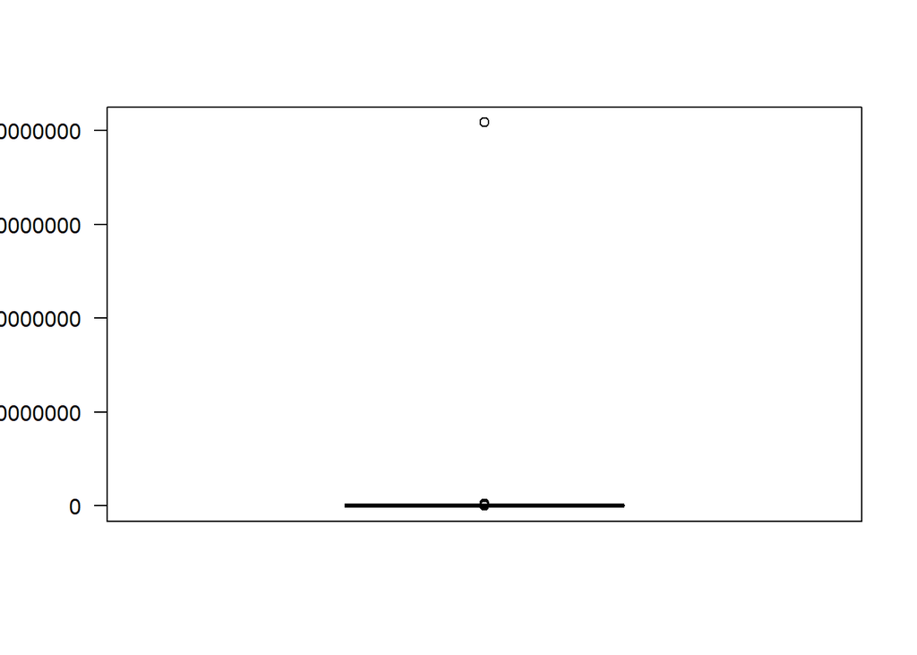

```r
boxplot(data$odometer, las=2)
```

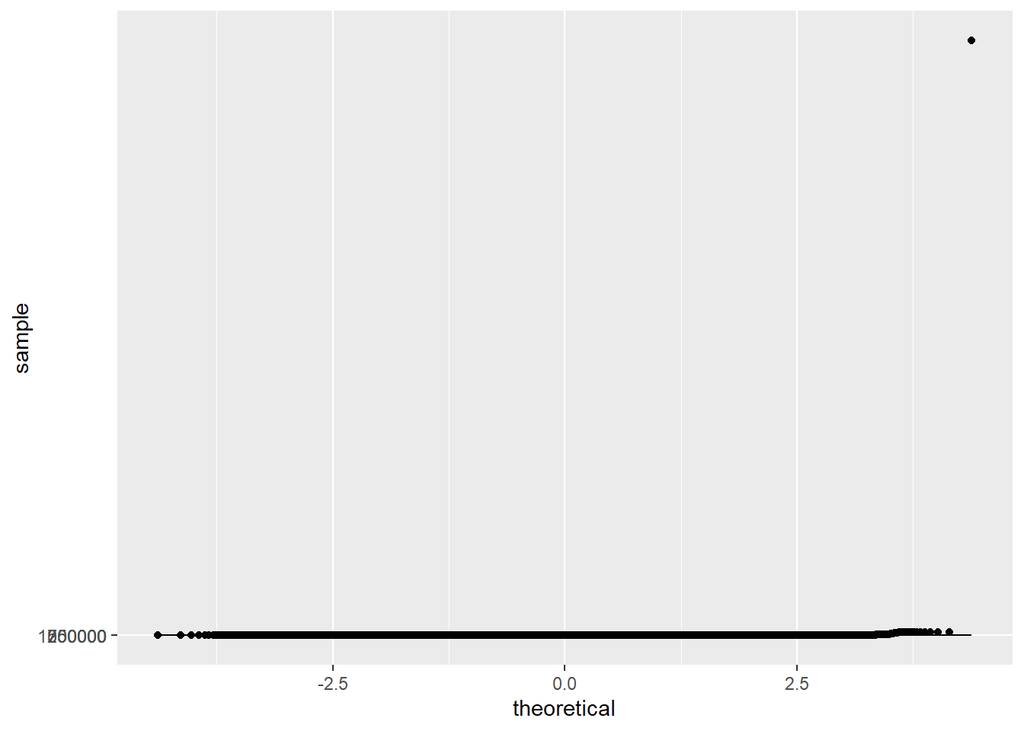

```r
ggplot(data = data, aes(sample=odometer)) +
  stat_qq() +
  stat_qq_line() +
  scale_y_continuous(breaks = seq(0, 1000000, by = 250000))
```

```r
data <- data[!data$odometer > 1000000, ]
```

Pouziť percentil alebo nepoužiť percentil ??

```r
data$odometer = percentil(data$odometer)
```

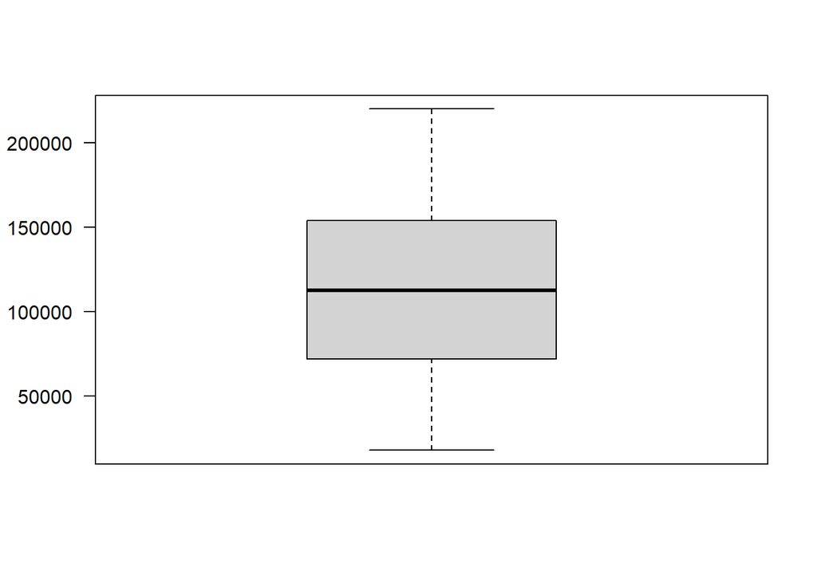

```r
boxplot(data$odometer, las=2)
```

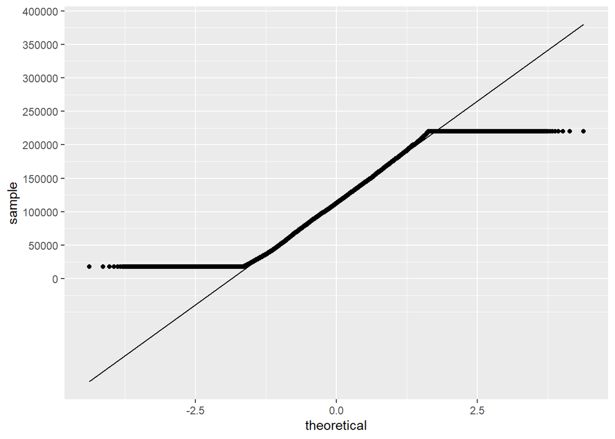

```r
ggplot(data = data, aes(sample=odometer)) +
  stat_qq() +
  stat_qq_line() +
  scale_y_continuous(breaks = seq(0, 5000000, by = 50000))
```

Väčšinu problémov ktoré sme mali sme vyriešili vymazaním týchto záznamov, alebo ich úpravou pomocou quartilov.

#### mid, west, east USA

Príprava dáta pre 4. hypotézu - podľa zemepisnej dĺžky rozdelíme inzeráty na východ, stred a západ USA.

```r
data$location <- ifelse(as.double(data$long) > -85, 'east',
  ifelse(as.double(data$long) < -110, 'west', 'mid')
)
```

## Overenie hypotéz

1. Cena vozidla je vyššia v prípade že v inzeráte je definované VIN číslo.
2. Trend počtu valcov v autách klesá spolu s rastúcim rokom (Môže za to downsizing motorov a snaha o odbremenenie životného prostredia)
3. Dieslové autá ktoré majú pohon na všetky kolesá zvyčajne majú v inzerátoch vyšší počet najazdených míľ.
4. Rozdeliť oblasť inzerátov na 3 časti východná, stredná a západná časť USA podľa súradníc a odsledovať, aké je rozdelenie využívaných aut a či je v strednej časti viac využívaných pickupov ako iných modelov.

## Bayes

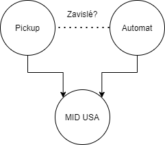

Pravdepodobnosť, že auto ma automat:

```r
print(nrow(data[data$transmission == "automatic", ])/nrow(data))
```

```
## [1] 0.9253391
```

```r
PA = nrow(data[data$transmission == "automatic", ])/nrow(data)
```

Pravdepodobnosť, že auto je pickup:

```r
print(nrow(data[data$type == "pickup", ])/nrow(data))
```

```
## [1] 0.07542993
```

```r
PP = nrow(data[data$type == "pickup", ])/nrow(data)
```

Pravdepodobnosti stavov P(M=1|P,A) MID = 1 PICKUP = 1 AUTOMAT = 1

```r
data_pick = data[data$type == "pickup", ]
data_pick_automat = data_pick[data_pick$transmission == "automatic", ]
data_pick_automat_mid =data_pick_automat[data_pick_automat$location == "mid", ]
Pm1p1a1 = nrow(data_pick_automat_mid) / nrow(data_pick_automat)
print(nrow(data_pick_automat_mid) / nrow(data_pick_automat))
```

```
## [1] 0.3709194
```

MID = 1 PICKUP = 1 AUTOMAT = 0

```r
data_pick = data[data$type == "pickup", ]
data_pick_automat = data_pick[!data_pick$transmission == "automatic", ]
data_pick_automat_mid =data_pick_automat[data_pick_automat$location == "mid", ]
Pm1p1a0 = nrow(data_pick_automat_mid) / nrow(data_pick_automat)
print(nrow(data_pick_automat_mid) / nrow(data_pick_automat))
```

```
## [1] 0.2829787
```

MID = 1 PICKUP = 0 AUTOMAT = 1

```r
data_pick = data[!data$type == "pickup", ]
data_pick_automat = data_pick[data_pick$transmission == "automatic", ]
data_pick_automat_mid =data_pick_automat[data_pick_automat$location == "mid", ]
Pm1p0a1 = nrow(data_pick_automat_mid) / nrow(data_pick_automat)
print(nrow(data_pick_automat_mid) / nrow(data_pick_automat))
```

```
## [1] 0.3499101
```

MID = 1 PICKUP = 0 AUTOMAT = 0

```r
data_pick = data[!data$type == "pickup", ]
data_pick_automat = data_pick[!data_pick$transmission == "automatic", ]
data_pick_automat_mid =data_pick_automat[data_pick_automat$location == "mid", ]
Pm1p0a0 = nrow(data_pick_automat_mid) / nrow(data_pick_automat)
print(nrow(data_pick_automat_mid) / nrow(data_pick_automat))
```

```
## [1] 0.2957225
```

Chceme overiť nezávislosť P a A. $\P(P,A|M) *(nevieme spočítať)* = P(A|M) * P(P|M)$ - tento vzťah musí platiť pokial maju byť javy nezávislé.

$\P(M=1|P,M) = sum_{P,A} P(M=1,P,A)*P(P)*P(A)$

```r
Pm1ap = Pm1p0a0*(1-PP)*(1-PA) + Pm1p0a1*(1-PP)*(PA) + Pm1p1a0*(PP)*(1-PA) + Pm1p1a1*(PP)*(PA)
Pm1ap
```

```
## [1] 0.347259
```